# Sentiment Analysis of Public Accounts Committee Oral Evidence Hearing

Exploratory analysis to understand the utility of sentiment analysis in evaluating qualiative information.

Luke Heley https://lajh87.github.io  
06-20-2021

# Objective

To explore the utility of sentiment analysis in evaluating qualitative information.

# Fetch and Preprocess Data

I extract a [House of Commons Public Accounts Committee Oral Evidence Hearing for the Inquiry into Defence Capabilities and the Equipment Plan (2019-2029)](https://committees.parliament.uk/oralevidence/429/html/) and tidy the data so that the dialogue is matched to the speaker and the question.

```r
document <- httr::GET("https://committees.parliament.uk/oralevidence/429/html/") %>%
  httr::content() %>%
  xml2::xml_find_all("//p") %>%
  xml2::xml_text()

meta <- document[1:19] # Can this be detected automatically?
text <- document[20:length(document)]

witnesses <- meta[18] %>%
  stringr::str_split(", | and |: |\\.") %>%
  unlist()

witnesses <- witnesses[2:6]
witnesses <- paste0(witnesses,":")
witnesses <- paste(witnesses, collapse = "|")

members <- meta[7:9] %>%
  stringr::str_split(", | and |: |\\.|and |; ") %>%
  unlist() %>%
  stringr::str_replace(" \\(Chair\\)", "")

stop_words <- c("", "Members present", "NAO Director",
                "Director of Parliamentary Relations",
                "Alternate Treasury Officer of Accounts",
                "were in attendance", "HM Treasury", "NAO",
                "Comptroller & Auditor General",
                "Liaison Committee member also present")

members <- members[!members %in% stop_words]
members <- paste0(members, ":")
members <- paste(members, collapse = "|")

people <- paste(members, witnesses,"Chair:", sep = "|")
questions <- "^Q[0-9]{3}|^Q[0-9]{2}|^Q[0-9]{1}"

tidy_text <- tibble::tibble(text) %>%
  dplyr::mutate(question = stringr::str_extract(text, questions)) %>%
  dplyr::mutate(person = stringr::str_extract(text, people)) %>%
  dplyr::mutate(person = stringr::str_sub(person, 1, nchar(person)-1)) %>%
  dplyr::mutate(dialogue = stringr::str_remove(text, people)) %>%
  dplyr::mutate(dialogue = stringr::str_remove(dialogue, questions)) %>%
  dplyr::mutate(dialogue = stringr::str_trim(dialogue)) %>%
  tidyr::fill(question, person, .direction = "down") %>%
  dplyr::select(question, person, dialogue) %>%
  dplyr::group_by(question, person) %>%
  tidyr::replace_na(list(question = "Opening"))

committee <- meta[2]
oral <- meta[3]
date <- meta[4]

meta_df <- tibble::tibble(committee, oral, date, members, witnesses)

tidy_document <- list(meta_df, body = tidy_text)
tidy_document
```

```
[[1]]
# A tibble: 1 x 5
  committee    oral           date    members         witnesses
  <chr>        <chr>          <chr>   <chr>           <chr>
1 Public Acco~ Oral evidence~ Thursd~ Meg Hillier:|G~ Sir Simon Bollo~

$body
# A tibble: 268 x 3
# Groups:   question, person [186]
   question person          dialogue
   <chr>    <chr>           <chr>
 1 Opening  Chair           Welcome to the Public Accounts Committee ~
 2 Opening  Chair           I would like to introduce our witnesses. ~
 3 Opening  Chair           We have a big job to get through today, i~
 4 Opening  Sir Stephen Lo~ I wish it had been quicker, candidly. It ~
 5 Opening  Sir Stephen Lo~ I think we are very, very close to the en~
 6 Q1       Chair           It is a real disappointment for something~
 7 Q1       Sir Stephen Lo~ Yes, of course. We have already made a nu~
 8 Q2       Chair           I would hope so, because an individual ma~
 9 Q2       Chair           Let me move on to the general issues rela~
10 Q2       Sir Stephen Lo~ It is certainly not to hide anything. Whe~
# ... with 258 more rows
```

# Sentiment Analysis

I use Tyler Rinker’s excellent [sentimentr](https://github.com/trinker/sentimentr/releases/tag/v2.6.1) package to calculate text polarity sentiment at the sentence level. This attempts to take into account valence shifters (i.e., negators, amplifiers (intensifiers), de-amplifiers (downtoners), and adversative conjunctions) while maintaining speed. By default `sentimentr` uses the [Jockers 2017](https://github.com/mjockers/syuzhet) dictionary.

## Sentiment by Person

The plot below shows the average sentiment by person and the variation in sentiment. Gareth Davies said the least, but was positive. The chair (Meg Hillier) had the most variation.

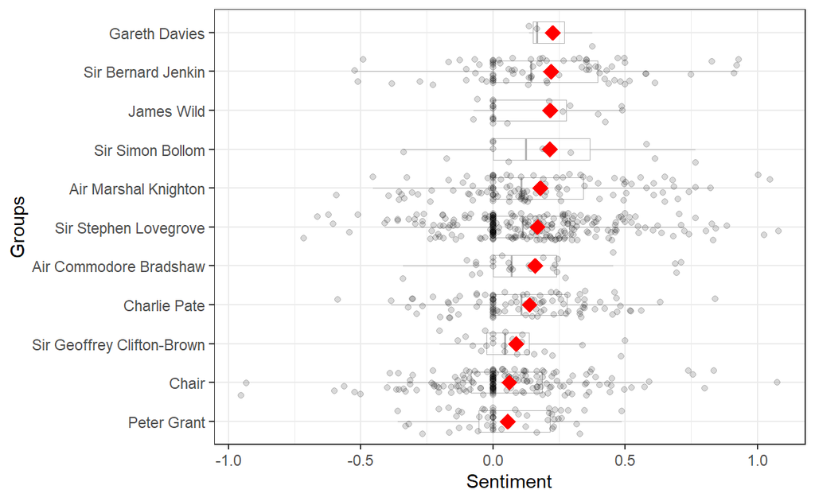

```r
tidy_document$body %>%
  dplyr::mutate(sentence = sentimentr::get_sentences(dialogue)) %$%
  sentimentr::sentiment_by(dialogue, list(person)) %>%
  plot()
```

## Sentiment by Question

The plot below shows the distribution of sentiment by question. The most positive question and response was Q71. The least positive was Q6. This is most useful in understanding the difficult questions the MOD faces.

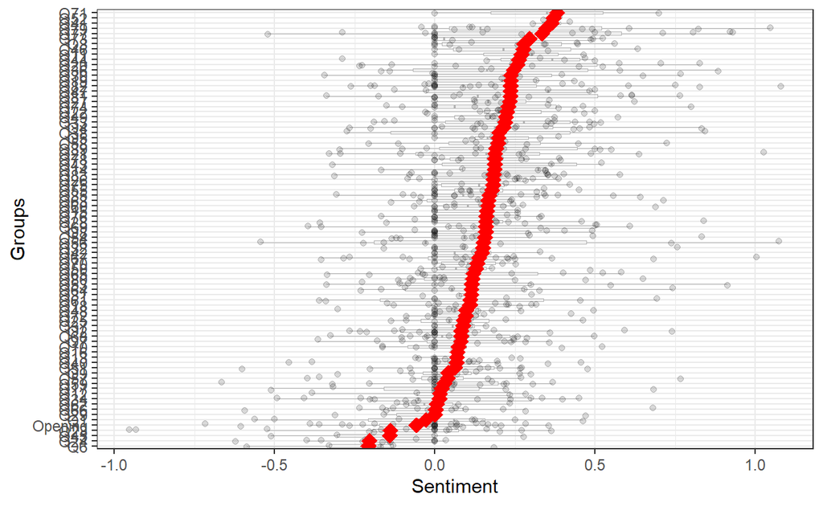

```r
tidy_document$body %>%
  dplyr::mutate(sentence = sentimentr::get_sentences(dialogue)) %$%
  sentimentr::sentiment_by(dialogue, list(question)) %>%
  plot()
```

## Emotional Valence Over Time

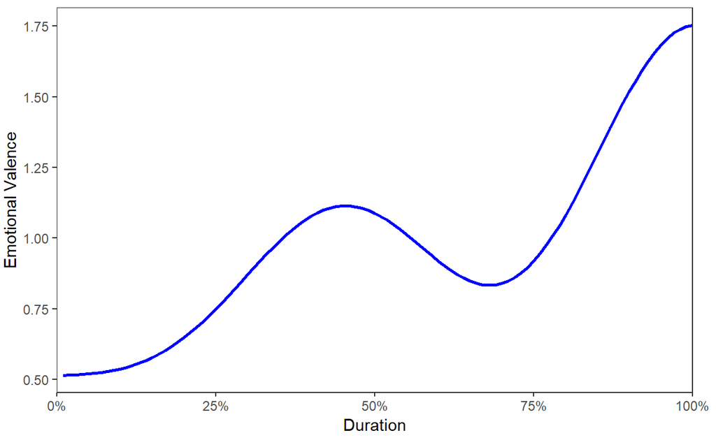

```r
tidy_document$body %>%
  dplyr::mutate(sentence = sentimentr::get_sentences(dialogue)) %$%
  sentimentr::sentiment_by(dialogue, list(person)) %>%
  sentimentr::uncombine() %>%
  plot()
```

## Highlighter Test

The `sentimentr` package contains a highlighter function that produces an HTML document with positive sentences highlighted green and negative sentences highlighted red. This is a useful tool to check the analysis.

```r
highlight_test <- tidy_document$body %>%
  dplyr::mutate(sentence = sentimentr::get_sentences(dialogue)) %$%
  sentimentr::sentiment_by(dialogue, list(question, person))

attr(highlight_test, "averaging.function") <- sentimentr::average_downweighted_zero
sentimentr::highlight(highlight_test,)
```

# Conclusion

Sentiment analysis has merit when analysing large volumes of data. It enable the user to see the variation in sentiment on aggregate, in groups and over time. This can help inform where to pay attention to specific elements of text.